# Biostat 203B Homework 5

Due Mar 22 @ 11:59PM

Author

Chuanliang Chen, UID: 106152237

## Predicting ICU duration

Using the ICU cohort `mimiciv_icu_cohort.rds` you built in Homework 4, develop at least three machine learning approaches (logistic regression with enet regularization, random forest, boosting, SVM, MLP, etc) plus a model stacking approach for predicting whether a patient’s ICU stay will be longer than 2 days. You should use the `los_long` variable as the outcome. You algorithms can use patient demographic information (gender, age at ICU `intime`, marital status, race), ICU admission information (first care unit), the last lab measurements before the ICU stay, and first vital measurements during ICU stay as features. You are welcome to use any feature engineering techniques you think are appropriate; but make sure to not use features that are not available at an ICU stay’s `intime`. For instance, `last_careunit` cannot be used in your algorithms.

1. Data preprocessing and feature engineering.
2. Partition data into 50% training set and 50% test set. Stratify partitioning according to `los_long`. For grading purpose, sort the data by `subject_id`, `hadm_id`, and `stay_id` and use the seed `203` for the initial data split. Below is the sample code.

```r
set.seed(203)

# sort
mimiciv_icu_cohort <- mimiciv_icu_cohort |>
  arrange(subject_id, hadm_id, stay_id)

data_split <- initial_split(
  mimiciv_icu_cohort,
  # stratify by los_long
  strata = "los_long",
  prop = 0.5
  )
```

3. Train and tune the models using the training set.
4. Compare model classification performance on the test set. Report both the area under ROC curve and accuracy for each machine learning algorithm and the model stacking. Interpret the results. What are the most important features in predicting long ICU stays? How do the models compare in terms of performance and interpretability?

```r
suppressPackageStartupMessages({
library(GGally)
library(gtsummary)
#library(keras)
library(ranger)
library(stacks)
library(tidyverse)
library(tidymodels)
library(xgboost)
})
```

```r
set.seed(203)

mimiciv_icu_cohort <- readRDS("mimiciv_icu_cohort.rds") %>%
  select(
    -deathtime, -discharge_location, -marital_status,
    -edregtime, -edouttime, -dod, -intime, -outtime, -admittime, -dischtime,
    -anchor_age, -anchor_year, -anchor_year_group, -last_careunit,
    -los, -gender, -age_at_intime
  )
colnames(mimiciv_icu_cohort)
```

```
 [1] "subject_id"
 [2] "hadm_id"
 [3] "stay_id"
 [4] "first_careunit"
 [5] "admission_type"
 [6] "admission_location"
 [7] "insurance"
 [8] "language"
 [9] "race"
[10] "hospital_expire_flag"
[11] "Bicarbonate"
[12] "Chloride"
[13] "Creatinine"
[14] "Glucose"
[15] "Potassium"
[16] "Sodium"
[17] "Hematocrit"
[18] "White Blood Cells"
[19] "Heart Rate"
[20] "Non Invasive Blood Pressure systolic"
[21] "Non Invasive Blood Pressure diastolic"
[22] "Respiratory Rate"
[23] "Temperature Fahrenheit"
[24] "los_long"
```

```r
mimiciv_icu_cohort <- mimiciv_icu_cohort |>
  arrange(subject_id, hadm_id, stay_id)

data_split <- initial_split(
  mimiciv_icu_cohort,
  # stratify by los_long
  strata = "los_long",
  prop = 0.5
  )
data_split
```

```
<Training/Testing/Total>
<36590/36591/73181>
```

```r
mimiciv_icu_cohort_other <- training(data_split) |>
  select(
    -subject_id, -hadm_id, -stay_id)
dim(mimiciv_icu_cohort_other)
```

```
[1] 36590    21
```

```r
mimiciv_icu_cohort_test <- testing(data_split)|>
  select(
    -subject_id, -hadm_id, -stay_id)
dim(mimiciv_icu_cohort_test)
```

```
[1] 36591    21
```

```r
mimiciv_icu_cohort_recipe <-
  recipe(
    los_long ~ .,
    data = mimiciv_icu_cohort_other
  ) |>
  step_impute_mean('Bicarbonate', 'Chloride', 'Creatinine', 'Potassium',
                   'Sodium', 'Hematocrit', 'White Blood Cells', 'Heart Rate',
                   'Non Invasive Blood Pressure systolic',
                   'Non Invasive Blood Pressure diastolic',
                   'Respiratory Rate', 'Temperature Fahrenheit', 'Glucose') |>
  #step_mutate(
    #Glucose = replace_na(Glucose, median(Glucose, na.rm = TRUE)),
    #role = "predictor") |>
  step_dummy(all_nominal_predictors()) |>
  # zero-variance filter
  step_zv(all_predictors())
  #step_normalize(all_numeric_predictors()) |>
mimiciv_icu_cohort_recipe
```

```
── Recipe ──────────────────────────────────────────────────────────────────────
```

```
── Inputs
```

```
Number of variables by role
```

```
outcome:    1
predictor: 20
```

```
── Operations
```

```
• Mean imputation for: "Bicarbonate", "Chloride", "Creatinine", ...
```

```
• Dummy variables from: all_nominal_predictors()
```

```
• Zero variance filter on: all_predictors()
```

```r
set.seed(203)
folds <- vfold_cv(mimiciv_icu_cohort_other, v = 5)
```

```r
logit_mod <-
  logistic_reg(
    penalty = tune(),
    mixture = tune()
  ) |>
  set_engine("glmnet", standardize = TRUE)
logit_mod
```

```
Logistic Regression Model Specification (classification)

Main Arguments:
  penalty = tune()
  mixture = tune()

Engine-Specific Arguments:
  standardize = TRUE

Computational engine: glmnet
```

```r
logit_wf <- workflow() |>
  add_recipe(mimiciv_icu_cohort_recipe) |>
  add_model(logit_mod)
logit_wf
```

```
══ Workflow ════════════════════════════════════════════════════════════════════
Preprocessor: Recipe
Model: logistic_reg()

── Preprocessor ────────────────────────────────────────────────────────────────
3 Recipe Steps

• step_impute_mean()
• step_dummy()
• step_zv()

── Model ───────────────────────────────────────────────────────────────────────
Logistic Regression Model Specification (classification)

Main Arguments:
  penalty = tune()
  mixture = tune()

Engine-Specific Arguments:
  standardize = TRUE

Computational engine: glmnet
```

```r
logit_grid <- grid_regular(
  penalty(range = c(-6, 3)),
  mixture(),
  levels = c(10, 5)
  )

logit_res <-
  tune_grid(
    object = logit_wf,
    resamples = folds,
    grid = logit_grid,
    control = control_stack_grid()
  )
```

```
ℹ The workflow being saved contains a recipe, which is 5.1 Mb in ℹ memory. If
this was not intentional, please set the control setting ℹ `save_workflow =
FALSE`.
```

```r
logit_res
```

```
# Tuning results
# 5-fold cross-validation
# A tibble: 5 × 5
  splits               id    .metrics           .notes           .predictions
  <list>               <chr> <list>             <list>           <list>
1 <split [29272/7318]> Fold1 <tibble [150 × 6]> <tibble [0 × 3]> <tibble>
2 <split [29272/7318]> Fold2 <tibble [150 × 6]> <tibble [0 × 3]> <tibble>
3 <split [29272/7318]> Fold3 <tibble [150 × 6]> <tibble [0 × 3]> <tibble>
4 <split [29272/7318]> Fold4 <tibble [150 × 6]> <tibble [0 × 3]> <tibble>
5 <split [29272/7318]> Fold5 <tibble [150 × 6]> <tibble [0 × 3]> <tibble>
```

```r
rf_mod <-
  rand_forest(
    mode = "classification",
    # Number of predictors randomly sampled in each split
    mtry = tune(),
    # Number of trees in ensemble
    trees = tune()
  ) |>
  set_engine("ranger")
rf_mod
```

```
Random Forest Model Specification (classification)

Main Arguments:
  mtry = tune()
  trees = tune()

Computational engine: ranger
```

```r
rf_wf <- workflow() |>
  add_recipe(mimiciv_icu_cohort_recipe) |>
  add_model(rf_mod)
rf_wf
```

```
══ Workflow ════════════════════════════════════════════════════════════════════
Preprocessor: Recipe
Model: rand_forest()

── Preprocessor ────────────────────────────────────────────────────────────────
3 Recipe Steps

• step_impute_mean()
• step_dummy()
• step_zv()

── Model ───────────────────────────────────────────────────────────────────────
Random Forest Model Specification (classification)

Main Arguments:
  mtry = tune()
  trees = tune()

Computational engine: ranger
```

```r
rf_grid <- grid_random(
  trees(range = c(120L, 140L)),
  mtry(range = c(2L, 3L)),
  size = 5
  )

rf_res <-
  tune_grid(
    object = rf_wf,
    resamples = folds,
    grid = rf_grid,
    control = control_stack_grid()
  )
```

```
ℹ The workflow being saved contains a recipe, which is 5.1 Mb in ℹ memory. If
this was not intentional, please set the control setting ℹ `save_workflow =
FALSE`.
```

```r
rf_res
```

```
# Tuning results
# 5-fold cross-validation
# A tibble: 5 × 5
  splits               id    .metrics          .notes           .predictions
  <list>               <chr> <list>            <list>           <list>
1 <split [29272/7318]> Fold1 <tibble [15 × 6]> <tibble [0 × 3]> <tibble>
2 <split [29272/7318]> Fold2 <tibble [15 × 6]> <tibble [0 × 3]> <tibble>
3 <split [29272/7318]> Fold3 <tibble [15 × 6]> <tibble [0 × 3]> <tibble>
4 <split [29272/7318]> Fold4 <tibble [15 × 6]> <tibble [0 × 3]> <tibble>
5 <split [29272/7318]> Fold5 <tibble [15 × 6]> <tibble [0 × 3]> <tibble>
```

```r
gb_mod <-
  boost_tree(
    mode = "classification",
    trees = 10,
    tree_depth = tune(),
    learn_rate = tune()
  ) |>
  set_engine("xgboost")
gb_mod
```

```
Boosted Tree Model Specification (classification)

Main Arguments:
  trees = 10
  tree_depth = tune()
  learn_rate = tune()

Computational engine: xgboost
```

```r
gb_wf <- workflow() |>
  add_recipe(mimiciv_icu_cohort_recipe) |>
  add_model(gb_mod)
gb_wf
```

```
══ Workflow ════════════════════════════════════════════════════════════════════
Preprocessor: Recipe
Model: boost_tree()

── Preprocessor ────────────────────────────────────────────────────────────────
3 Recipe Steps

• step_impute_mean()
• step_dummy()
• step_zv()

── Model ───────────────────────────────────────────────────────────────────────
Boosted Tree Model Specification (classification)

Main Arguments:
  trees = 10
  tree_depth = tune()
  learn_rate = tune()

Computational engine: xgboost
```

```r
gb_grid <- grid_regular(
  tree_depth(range = c(1L, 3L)),
  learn_rate(range = c(-2, 1), trans = log10_trans()),
  levels = c(3, 5)
  )

gb_res <-
  tune_grid(
    object = gb_wf,
    resamples = folds,
    grid = gb_grid,
    control = control_stack_grid()
  )
```

```
ℹ The workflow being saved contains a recipe, which is 5.1 Mb in ℹ memory. If
this was not intentional, please set the control setting ℹ `save_workflow =
FALSE`.
```

```r
gb_res
```

```
# Tuning results
# 5-fold cross-validation
# A tibble: 5 × 5
  splits               id    .metrics          .notes           .predictions
  <list>               <chr> <list>            <list>           <list>
1 <split [29272/7318]> Fold1 <tibble [45 × 6]> <tibble [0 × 3]> <tibble>
2 <split [29272/7318]> Fold2 <tibble [45 × 6]> <tibble [0 × 3]> <tibble>
3 <split [29272/7318]> Fold3 <tibble [45 × 6]> <tibble [0 × 3]> <tibble>
4 <split [29272/7318]> Fold4 <tibble [45 × 6]> <tibble [0 × 3]> <tibble>
5 <split [29272/7318]> Fold5 <tibble [45 × 6]> <tibble [0 × 3]> <tibble>
```

```r
mimiciv_icu_cohort_st <-
  stacks() |>
  add_candidates(logit_res) |>
  add_candidates(rf_res) |>
  add_candidates(gb_res) |>
  blend_predictions(
    penalty = 10^(-2:1),
    #penalty = 10^(-6:2),
    times = 1,
    metrics = c("roc_auc")
    ) |>
  fit_members()
```

```r
mimiciv_icu_cohort_st
```

```
── A stacked ensemble model ─────────────────────────────────────


Out of 38 possible candidate members, the ensemble retained 7.

Penalty: 0.01.

Mixture: 1.


The 7 highest weighted member classes are:
```

```
# A tibble: 7 × 3
  member                    type         weight
  <chr>                     <chr>         <dbl>
1 .pred_TRUE_rf_res_1_1     rand_forest  1.35
2 .pred_TRUE_rf_res_1_3     rand_forest  1.25
3 .pred_TRUE_gb_res_1_12    boost_tree   0.754
4 .pred_TRUE_rf_res_1_5     rand_forest  0.743
5 .pred_TRUE_rf_res_1_4     rand_forest  0.703
6 .pred_TRUE_rf_res_1_2     rand_forest  0.373
7 .pred_TRUE_logit_res_1_01 logistic_reg 0.0538
```

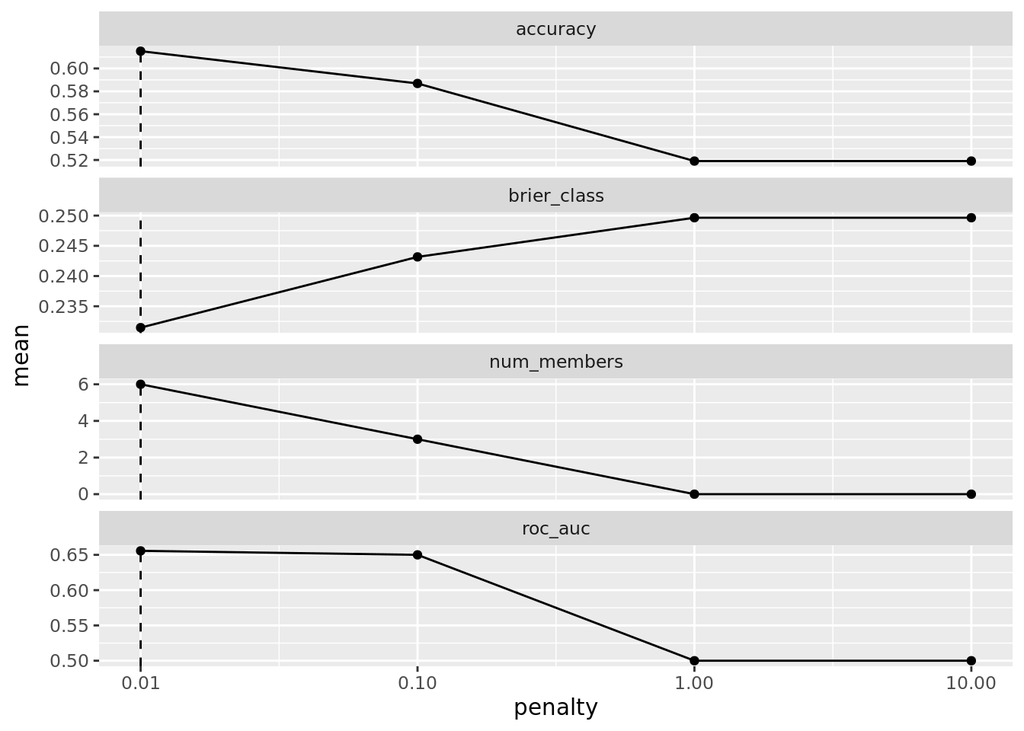

```r
autoplot(mimiciv_icu_cohort_st)
```

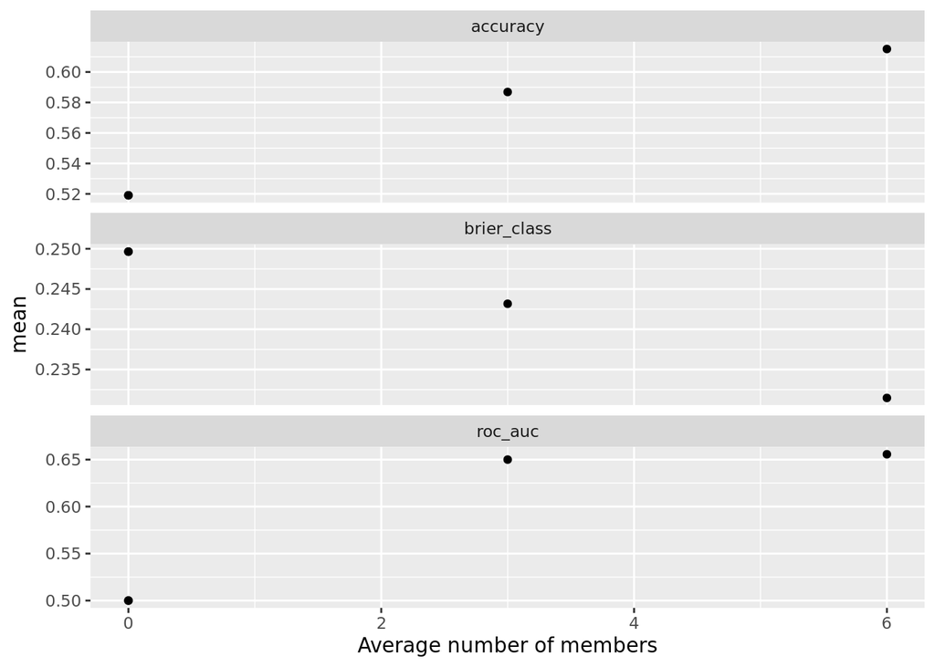

```r
autoplot(mimiciv_icu_cohort_st, type = "members")
```